# week_15_regularize_enet

## CMPINF 2100

### Introduction to Regularization using Logistic Regression - ELASIC NET (ENET)

This notebook will build from a starting point and eventually show you how to TUNE regularization methods using scikit-learn from Logistic Regression.

## Import Modules

```python
import numpy as np
import pandas as pd
import matplotlib.pyplot as plt

import seaborn as sns
```

## Read data

We will continue to use the binary classification example from Week 12.

```python
df = pd.read_csv("../week_13/week_12_binary_classification.csv")
```

```python
df.info()
```

```
<class 'pandas.core.frame.DataFrame'>
RangeIndex: 300 entries, 0 to 299
Data columns (total 6 columns):
 #   Column  Non-Null Count  Dtype
---  ------  --------------  -----
 0   x1      300 non-null    float64
 1   x2      300 non-null    float64
 2   x3      300 non-null    float64
 3   x4      300 non-null    float64
 4   x5      300 non-null    object
 5   y       300 non-null    int64
dtypes: float64(4), int64(1), object(1)
memory usage: 14.2+ KB
```

```python
df.nunique()
```

```
x1    300
x2    300
x3    300
x4    300
x5      3
y       2
dtype: int64
```

## Logistic Regression

We have fit MANY model from SIMPLE to COMPLEX.

```python
formula_list = ["y ~ 1",
               "y ~ x5",
               "y ~ x1 + x2 + x3 + x4",
               "y ~ x1 + x2 + x3 + x4 + x5",
               "y ~ x5 * (x1 + x2 + x3 + x4)",
               "y ~ (x1 + x2 + x3 + x4) ** 2",
               "y ~ x1 + x2 + x3 + x4 + np.power(x1, 2) + np.power(x2 ,2) + np.power(x3 ,2) + np.power(x4 ,2)",
               "y ~ x5 + x1 + x2 + x3 + x4 + np.power(x1, 2) + np.power(x2 ,2) + np.power(x3 ,2) + np.power(x4 ,2)",
               "y ~ x5 * (x1 + x2 + x3 + x4 + np.power(x1, 2) + np.power(x2 ,2) + np.power(x3 ,2) + np.power(x4 ,2))",
               "y ~ x5 + ((x1 + x2 + x3 + x4) ** 2 + np.power(x1, 2) + np.power(x2 ,2) + np.power(x3 ,2) + np.power(x4 ,2))",
               "y ~ x5 * ((x1 + x2 + x3 + x4) ** 2 + np.power(x1, 2) + np.power(x2 ,2) + np.power(x3 ,2) + np.power(x4 ,2))",
               "y ~ x5 + (x1 + x2 + x3 + x4) ** 3",
               "y ~ x5 + (x1 + x2 + x3 + x4) ** 4",
               "y ~ (x1 + x2 + x3 + x4 + x5) ** 3",
               "y ~ (x1 + x2 + x3 + x4 + x5) ** 4",
               "y ~ x5 * ( (x1 + x2 + x3 + x4) ** 3 + np.power(x1, 2) + np.power(x2 ,2) + np.power(x3 ,2) + np.power(x4 ,2) + np.power(x1, 3) + np.power(x2 ,3) + np.power(x3 ,3) + np.power(x4 ,3))",
               "y ~ x5 * ( (x1 + x2 + x3 + x4) ** 3 + np.power(x1, 2) + np.power(x2 ,2) + np.power(x3 ,2) + np.power(x4 ,2) + np.power(x1, 3) + np.power(x2 ,3) + np.power(x3 ,3) + np.power(x4 ,3) + np.power(x1, 4) + np.power(x2 ,4) + np.power(x3 ,4) + np.power(x4 ,4))"
               ]
```

```python
formula_list[0]
```

```
'y ~ 1'
```

```python
formula_list[-1]
```

```
'y ~ x5 * ( (x1 + x2 + x3 + x4) ** 3 + np.power(x1, 2) + np.power(x2 ,2) + np.power(x3 ,2) + np.power(x4 ,2) + np.power(x1, 3) + np.power(x2 ,3) + np.power(x3 ,3) + np.power(x4 ,3) + np.power(x1, 4) + np.power(x2 ,4) + np.power(x3 ,4) + np.power(x4 ,4))'
```

We know how to fit the models with statsmodels.

```python
import statsmodels.formula.api as smf
```

```python
fit_stats = smf.logit(formula=formula_list[-1], data=df).fit()
```

```
Optimization terminated successfully.
         Current function value: 0.335107
         Iterations 12
```

```python
fit_stats.params
```

```
Intercept                  1.320581
x5[T.b]                   -1.552826
x5[T.c]                   -0.022902
x1                        -0.998869
x5[T.b]:x1                 1.210213
                             ...
x5[T.b]:np.power(x3, 4)    0.416084
x5[T.c]:np.power(x3, 4)    0.224892
np.power(x4, 4)            0.284632
x5[T.b]:np.power(x4, 4)   -0.394857
x5[T.c]:np.power(x4, 4)   -1.348794
Length: 81, dtype: float64
```

```python
fit_stats.bse
```

```
Intercept                  1.372893
x5[T.b]                    1.540143
x5[T.c]                    1.749245
x1                         1.730182
x5[T.b]:x1                 1.887524
                             ...
x5[T.b]:np.power(x3, 4)    0.301682
x5[T.c]:np.power(x3, 4)    0.789798
np.power(x4, 4)            0.324309
x5[T.b]:np.power(x4, 4)    0.339964
x5[T.c]:np.power(x4, 4)    0.870452
Length: 81, dtype: float64
```

```python
fit_stats.conf_int()
```

|  | 0 | 1 |
| --- | --- | --- |
| Intercept | -1.370239 | 4.011401 |
| x5[T.b] | -4.571452 | 1.465799 |
| x5[T.c] | -3.451359 | 3.405555 |
| x1 | -4.389963 | 2.392224 |
| x5[T.b]:x1 | -2.489267 | 4.909692 |
| ... | ... | ... |
| x5[T.b]:np.power(x3, 4) | -0.175201 | 1.007369 |
| x5[T.c]:np.power(x3, 4) | -1.323083 | 1.772867 |
| np.power(x4, 4) | -0.351002 | 0.920266 |
| x5[T.b]:np.power(x4, 4) | -1.061174 | 0.271460 |
| x5[T.c]:np.power(x4, 4) | -3.054848 | 0.357261 |

81 rows × 2 columns

```python
fit_stats.params.to_numpy()
```

```
array([ 1.32058095, -1.55282638, -0.02290171, -0.9988693 ,  1.2102127 ,
        4.66947597,  1.90020218, -2.80989522,  0.01302911,  2.48168371,
       -0.96904051, -3.70302173, -2.00940075,  2.05631202, -1.42985181,
       -1.96785309,  3.25014955, -2.70804585, -0.58525923,  0.05788615,
        2.25275043,  0.89524115, -1.68284148,  1.52848922, -1.14562035,
        2.31962476,  3.7961458 , -0.50683116,  0.46859127,  1.42882239,
        1.31683802, -1.20552019,  1.06433771, -0.34984964,  0.29108868,
       -5.68198569,  0.73811828, -0.97567907, -5.31258558,  0.51251628,
       -0.23690389, -1.06781236, -0.88103307,  0.95685953, -1.40207326,
        0.78548406,  0.32390322, -6.11743806, -0.39173843, -1.41806941,
        1.74981065, -2.08533623, -0.07217375, -0.85639912, -1.18932018,
        1.95855023,  7.7673739 ,  1.54691021, -0.69605481, -1.9847706 ,
       -4.90112106,  3.96307639,  3.21648377, -0.60610656,  0.63119099,
        0.994993  ,  0.4187507 , -0.44076032,  1.67639326, -1.16383033,
        0.22411703,  1.55291441, -1.85416787,  1.71526835,  0.3571432 ,
        0.26337718,  0.41608366,  0.22489186,  0.28463175, -0.39485659,
       -1.34879377])
```

We also know how to fit the models with sklearn using the ARRAY interface.

```python
from sklearn.linear_model import LogisticRegression
```

```python
from patsy import dmatrices, dmatrix
```

We know about the "HACK" for force sklearn to behave like statsmodels. We use the SAME formula as statsmodels to create the FEATURE ARRAY but we must CHANGE the default and typical arguments for sklearn.

Lets begin with the INTERCEPT ONLY or the SIMPLEST possible model.

```python
y_0, x_0 = dmatrices(formula_list[0], data=df)
```

```python
x_0.shape
```

```
(300, 1)
```

```python
y_0.shape
```

```
(300, 1)
```

```python
x_0[:5]
```

```
array([[1.],
       [1.],
       [1.],
       [1.],
       [1.]])
```

```python
fit_sk_0 = LogisticRegression(penalty=None, solver="lbfgs", max_iter=25001, fit_intercept=False).fit(x_0, y_0.ravel())
```

```python
fit_sk_0.coef_
```

```
array([[-0.66329422]])
```

```python
fit_sk_0.score(x_0, y_0.ravel())
```

```
0.66
```

```python
df.y.value_counts(normalize=True)
```

```
y
0    0.66
1    0.34
Name: proportion, dtype: float64
```

But the MOST COMPLEX model that we FIT did very well on the TRAINING SET!!! It appeared to be the BEST according to the TRAINING SET!!

```python
y_sk, x_sk = dmatrices(formula_list[-1], data=df)
```

```python
x_sk.shape
```

```
(300, 81)
```

```python
y_sk.shape
```

```
(300, 1)
```

```python
y_sk[:5]
```

```
array([[1.],
       [0.],
       [0.],
       [1.],
       [0.]])
```

```python
fit_sk_none = LogisticRegression(penalty=None, solver="lbfgs", max_iter=25001, fit_intercept=False).fit(x_sk, y_sk.ravel())
```

```python
fit_sk_none.coef_
```

```
array([[ 1.32903776e+00, -1.56139051e+00, -3.27902978e-02,
        -9.88950601e-01,  1.19989015e+00,  4.65651434e+00,
         1.91247533e+00, -2.82302232e+00, -2.72736626e-03,
         2.47897384e+00, -9.65756754e-01, -3.69845021e+00,
        -2.01122762e+00,  2.05793123e+00, -1.42447577e+00,
        -1.96675913e+00,  3.24913479e+00, -2.70460476e+00,
        -5.84326984e-01,  5.71266467e-02,  2.25025678e+00,
         8.95428711e-01, -1.68319489e+00,  1.52640051e+00,
        -1.14058265e+00,  2.31507854e+00,  3.78737356e+00,
        -5.03358049e-01,  4.64973628e-01,  1.41966754e+00,
         1.31450464e+00, -1.20298447e+00,  1.06428509e+00,
        -3.48554814e-01,  2.90291125e-01, -5.67919062e+00,
         7.45937589e-01, -9.83142045e-01, -5.31674325e+00,
         5.12225332e-01, -2.37217292e-01, -1.06630195e+00,
        -8.83520143e-01,  9.59606983e-01, -1.39739532e+00,
         7.72561228e-01,  3.36893985e-01, -6.09854713e+00,
        -3.90434440e-01, -1.41990750e+00,  1.74538886e+00,
        -2.08522325e+00, -7.28171259e-02, -8.54433014e-01,
        -1.19203294e+00,  1.96157028e+00,  7.76650349e+00,
         1.53927322e+00, -6.87848866e-01, -1.97657129e+00,
        -4.91438780e+00,  3.97672416e+00,  3.23162514e+00,
        -6.05296423e-01,  6.30231237e-01,  9.93025824e-01,
         4.18508939e-01, -4.40476475e-01,  1.67457439e+00,
        -1.15776264e+00,  2.17805292e-01,  1.54590959e+00,
        -1.85989270e+00,  1.72120422e+00,  3.65203740e-01,
         2.63344716e-01,  4.16293439e-01,  2.24490844e-01,
         2.84389436e-01, -3.94640012e-01, -1.34826592e+00]])
```

```python
fit_sk_none.score(x_sk, y_sk.ravel())
```

```
0.8133333333333334
```

The MOST complex model APPEARED to be the BEST on the TRAINING set but... CV revealed that this model was ON AVERAGE **WORSE** than the INTERCEPT-ONLY or SIMPLEST possible model on **NEW** data!!!

## Why did we need the "HACK"?

Or what does the penalty argument mean??

Our most COMPLEX model **CONTAINS** the FEATURES from the other simpler models! THe mode complex model is a SUPER SET containing all features from all other models.

But our MOST COMPLEX model has SO MANY FEATURES that it **OVERFITS** the training data! It memorizes the "past" and does VERY POORLY on the "future".

However, what if we could REMOVE or TURN OFF features from this most complex mode? What if we could identify the FEATURES that do **NOT** matter and REMOVE THEM by setting their coefficients (slopes) = 0.

#### This idea of using a method to FORCE coefficients to ZERO if the features does NOT matter is known as **REGULARIZATION** OR **PENALIZATION**.

How does this work? We fit models by MINIMIZING A LOSS. The LOSS depends on the COEFFICIENTS.

FIND the COEFFICIENTS that MINIMIZE the LOSS.

BUT REGULARIZATION **modifies** this approach. Instead of ONLY minimizing the LOSS, REGULARIZATION **adds** a PENALTY!

#### FIND the COEFFICIENTS that MINIMIZE the **sum** of the LOSS and the PENALTY.

#### If large or extreme coefficients cause the LOSS to become SMALL **but** also cause the PENALTY to become LARGE, then those coefficients values will **NOT** be identified.

## What kind of PENALTIES exist?

There are many varieties of PENALTIES or REGULARIZATION approaches. We will demonstrate the 3 main types.

We will cover RIDGE, LASSO, and ELASTIC NET.

## 1. Ridge penalty

The RIDGE penalty also known as L2-norm penalty is the **DEFAULT** PENALTY used by LogisticRegression function. Therefore if you do NOT set penalty argument the RIDGE penalty is ASSUMED.

However, I always recommend MANUALLY setting the penalty argument so that you KNOW exactly what PENALTY you are working with!!

ALL REGULARIZATION or PENALIZATION methods include an additional PARAMETER that **CONTROLS** how the coefficients are estimated. LogisticRegression function names this PARAMETER C. The C parameter has DEFAULT value of 1. The C paramter **MUST** always have a VALUE for RIDGE!!!

But, what this means is we need to understand **HOW** the C parameter **IMPACTS** the coefficient estimates as part of the RIDGE penalty!!!

Lets try 3 different values of C on our problem for the RIDGE penalty!!!

Lets BEGIN with the **DEFAULT** C Parameter value for RIDGE.

```python
ridge_default_C = LogisticRegression(penalty="l2", C=1.0, solver="lbfgs", max_iter=25001, fit_intercept=False).\
fit(x_sk, y_sk.ravel())
```

```python
ridge_default_C.score(x_sk, y_sk.ravel())
```

```
0.8033333333333333
```

REMEMBER the SCORE when we FORCED sklearn to behave LIKE statsmodels and thus ONLY minimize the LOSS and have NO penalty.

```python
fit_sk_none.score(x_sk, y_sk.ravel())
```

```
0.8133333333333334
```

Why does the TRAINING set accuracy change? Because the RIDGE coefficient estimates do NOT equal the estimates that MINIMIZE the LOSS!!

```python
ridge_default_C.coef_
```

```
array([[ 0.35190334, -0.61044789,  0.34078395,  0.05770284,  0.0727223 ,
         0.39651355, -0.40064119, -0.04861788,  0.31767744,  0.65891749,
         0.50142922, -0.8373951 , -0.60571116,  0.49512341, -0.50873119,
        -0.29576994,  1.17724226, -0.76409511, -0.30567563, -0.08884968,
         0.31560349,  0.31583152, -0.81527217,  0.2364953 ,  0.18029631,
         0.58310441, -0.07813379, -0.30929655,  0.20471177,  0.1458866 ,
         0.34910984, -0.19526741,  0.07799484, -0.32092639,  0.20323695,
        -0.5788551 ,  0.31044183, -0.34596634,  0.29153796, -0.20242872,
         0.38568757, -0.20323107, -0.40050948,  0.43507038, -0.48761937,
         0.31069018,  0.28990854, -0.37609256, -0.15038369, -1.03153757,
         0.30013169, -0.86184555, -0.56242829,  0.07772459,  0.19135473,
         0.35445005,  0.38665148,  0.4818172 ,  0.13200065,  0.05801115,
        -0.9307249 ,  0.0467803 ,  0.21502475, -0.18976779,  0.17920249,
         0.10792937,  0.10220049, -0.0820685 ,  0.4047779 , -0.53280483,
        -0.07743978,  0.07978892, -0.3589272 ,  0.15685278, -0.1633578 ,
         0.10412033,  0.3538822 , -0.00328474, -0.0149368 , -0.05656461,
        -0.08074132]])
```

The COEFFICIENT estimates are DIFF compared to statsmodels!!

But to really understand the impact of C we neeed to try EXTREME CASES. Lets first set C to a VERY LARGE value.

```python
ridge_large_C = LogisticRegression(penalty="l2", C=10000, solver="lbfgs", max_iter=25001, fit_intercept=False).\
fit(x_sk, y_sk.ravel())
```

```python
ridge_large_C.score(x_sk, y_sk.ravel())
```

```
0.8133333333333334
```

```python
fit_sk_none.score(x_sk, y_sk.ravel())
```

```
0.8133333333333334
```

The TRAINING SET accuracy is the SAME as when NO penalty is applied when the C parameter is very LARGE!!!

The coefficients...

```python
ridge_large_C.coef_
```

```
array([[ 1.32137559e+00, -1.55414413e+00, -2.64856031e-02,
        -9.96107472e-01,  1.20779446e+00,  4.64032899e+00,
         1.89245594e+00, -2.80181709e+00,  6.93106586e-03,
         2.48040260e+00, -9.67833032e-01, -3.69624760e+00,
        -2.01074547e+00,  2.05753938e+00, -1.41976025e+00,
        -1.96385809e+00,  3.24596844e+00, -2.67897985e+00,
        -5.85984164e-01,  5.87420608e-02,  2.24140384e+00,
         8.94938533e-01, -1.68233404e+00,  1.51029507e+00,
        -1.14018391e+00,  2.31388010e+00,  3.77130660e+00,
        -5.07308693e-01,  4.68985090e-01,  1.43723877e+00,
         1.31596433e+00, -1.20454475e+00,  1.04961460e+00,
        -3.51542966e-01,  2.92790895e-01, -5.63392893e+00,
         7.37885952e-01, -9.75139597e-01, -5.26294439e+00,
         5.09793599e-01, -2.34294419e-01, -1.07170522e+00,
        -8.78864139e-01,  9.54760367e-01, -1.40278954e+00,
         7.80862593e-01,  3.29190323e-01, -6.07463849e+00,
        -3.93932793e-01, -1.41522027e+00,  1.74698258e+00,
        -2.08447797e+00, -7.23466759e-02, -8.40515731e-01,
        -1.18806902e+00,  1.95736254e+00,  7.70920720e+00,
         1.54382189e+00, -6.93461304e-01, -1.97445480e+00,
        -4.89141924e+00,  3.95329450e+00,  3.21419058e+00,
        -6.05926164e-01,  6.30890490e-01,  9.92495603e-01,
         4.19256698e-01, -4.41260405e-01,  1.66803419e+00,
        -1.16111472e+00,  2.21298176e-01,  1.54662514e+00,
        -1.84920601e+00,  1.71014696e+00,  3.56720387e-01,
         2.63379206e-01,  4.15866427e-01,  2.20872750e-01,
         2.84315899e-01, -3.94544727e-01, -1.33853655e+00]])
```

So LARGE VALUES for C **allow** large coefficient estimates!!!

Lets now try the OTHER EXTREME a VERY SMALL value of C.

```python
ridge_small_C = LogisticRegression(penalty="l2", C=0.0001, solver="lbfgs", max_iter=25001, fit_intercept=False).\
fit(x_sk, y_sk.ravel())
```

```python
ridge_small_C.score(x_sk, y_sk.ravel())
```

```
0.6633333333333333
```

```python
fit_sk_none.score(x_sk, y_sk.ravel())
```

```
0.8133333333333334
```

```python
fit_sk_0.score(x_0, y_0.ravel())
```

```
0.66
```

Very SMALL values of C cause the training set accuracy to behave LIKE the INTERCEPT ONLY model..the SIMPLEST POSSIBLE MODEL!! We are getting the same performance as a model that has NO TREND or NO FEATURES!!!

This occurs because the COEFFICIENT ESTIMATES are now VERY SMALL!!!

```python
ridge_small_C.coef_
```

```
array([[-3.33742356e-03, -2.50272458e-03, -2.60550054e-04,
         1.82571313e-03,  5.09871548e-04,  9.85762629e-04,
        -3.45992238e-03, -1.30602505e-03, -1.32112976e-03,
         1.10031034e-03,  1.28086397e-03, -2.92374728e-05,
        -1.69635912e-04, -3.53120431e-04,  2.23010015e-04,
        -5.13597377e-04,  2.39197785e-04, -4.92323612e-04,
        -2.12475470e-04,  5.58107371e-05,  9.16338489e-05,
        -1.59641695e-04, -6.09169373e-04,  1.49964565e-04,
         1.04872762e-03,  9.98886854e-04, -2.87102570e-04,
        -3.02517955e-04, -2.24400952e-04, -1.11208788e-04,
         1.16199673e-03, -3.57889697e-05,  7.18448853e-04,
        -8.44474538e-04,  4.87348861e-04, -7.79061812e-04,
         3.14456935e-04,  1.00287709e-04,  2.63308211e-04,
         6.15364541e-04,  7.89438311e-04, -2.38624152e-05,
        -8.08429912e-04, -4.31285915e-04, -2.53305371e-04,
        -5.82334590e-03, -2.92779188e-03, -1.07468225e-03,
        -4.98345164e-03, -3.29194119e-03, -1.07736181e-03,
        -4.20305889e-03, -2.02690804e-03, -4.97969567e-04,
        -1.97578913e-03, -1.76138615e-03, -6.52294879e-04,
         3.07509832e-03,  2.04267453e-03,  2.03417145e-03,
        -6.79775617e-03, -3.09605122e-03, -2.81559372e-03,
         1.12574452e-03,  2.60375220e-03,  2.14423793e-04,
         1.11772725e-03, -1.65285522e-03,  1.98381003e-03,
        -2.02328168e-02, -8.16618043e-03, -4.00134433e-03,
        -1.58777045e-02, -8.02040238e-03, -4.69671028e-03,
        -1.14898989e-02, -3.57911208e-03, -2.14079361e-03,
         2.04866998e-04, -2.54027945e-03, -2.28178312e-03]])
```

Lets directly compare the RIDGE estimates for DIFF values of C with the statsmodel results!

```python
coef_compare = pd.DataFrame({"statsmodels": fit_stats.params})
```

```python
coef_compare
```

|  | statsmodels |
| --- | --- |
| Intercept | 1.320581 |
| x5[T.b] | -1.552826 |
| x5[T.c] | -0.022902 |
| x1 | -0.998869 |
| x5[T.b]:x1 | 1.210213 |
| ... | ... |
| x5[T.b]:np.power(x3, 4) | 0.416084 |
| x5[T.c]:np.power(x3, 4) | 0.224892 |
| np.power(x4, 4) | 0.284632 |
| x5[T.b]:np.power(x4, 4) | -0.394857 |
| x5[T.c]:np.power(x4, 4) | -1.348794 |

81 rows × 1 columns

```python
coef_compare["sk_none"] = pd.Series(fit_sk_none.coef_.ravel(), index=coef_compare.index)
```

```python
coef_compare
```

|  | statsmodels | sk_none |
| --- | --- | --- |
| Intercept | 1.320581 | 1.329038 |
| x5[T.b] | -1.552826 | -1.561391 |
| x5[T.c] | -0.022902 | -0.032790 |
| x1 | -0.998869 | -0.988951 |
| x5[T.b]:x1 | 1.210213 | 1.199890 |
| ... | ... | ... |
| x5[T.b]:np.power(x3, 4) | 0.416084 | 0.416293 |
| x5[T.c]:np.power(x3, 4) | 0.224892 | 0.224491 |
| np.power(x4, 4) | 0.284632 | 0.284389 |
| x5[T.b]:np.power(x4, 4) | -0.394857 | -0.394640 |
| x5[T.c]:np.power(x4, 4) | -1.348794 | -1.348266 |

81 rows × 2 columns

Add in columns for the RIDGE estimates.

```python
coef_compare["ridge_large_c"] = pd.Series(ridge_large_C.coef_.ravel(), index=coef_compare.index)
```

```python
coef_compare
```

|  | statsmodels | sk_none | ridge_large_c |
| --- | --- | --- | --- |
| Intercept | 1.320581 | 1.329038 | 1.321376 |
| x5[T.b] | -1.552826 | -1.561391 | -1.554144 |
| x5[T.c] | -0.022902 | -0.032790 | -0.026486 |
| x1 | -0.998869 | -0.988951 | -0.996107 |
| x5[T.b]:x1 | 1.210213 | 1.199890 | 1.207794 |
| ... | ... | ... | ... |
| x5[T.b]:np.power(x3, 4) | 0.416084 | 0.416293 | 0.415866 |
| x5[T.c]:np.power(x3, 4) | 0.224892 | 0.224491 | 0.220873 |
| np.power(x4, 4) | 0.284632 | 0.284389 | 0.284316 |
| x5[T.b]:np.power(x4, 4) | -0.394857 | -0.394640 | -0.394545 |
| x5[T.c]:np.power(x4, 4) | -1.348794 | -1.348266 | -1.338537 |

81 rows × 3 columns

```python
coef_compare["ridge_default_c"] = pd.Series(ridge_default_C.coef_.ravel(), index=coef_compare.index)
```

```python
coef_compare
```

|  | statsmodels | sk_none | ridge_large_c | ridge_default_c |
| --- | --- | --- | --- | --- |
| Intercept | 1.320581 | 1.329038 | 1.321376 | 0.351903 |
| x5[T.b] | -1.552826 | -1.561391 | -1.554144 | -0.610448 |
| x5[T.c] | -0.022902 | -0.032790 | -0.026486 | 0.340784 |
| x1 | -0.998869 | -0.988951 | -0.996107 | 0.057703 |
| x5[T.b]:x1 | 1.210213 | 1.199890 | 1.207794 | 0.072722 |
| ... | ... | ... | ... | ... |
| x5[T.b]:np.power(x3, 4) | 0.416084 | 0.416293 | 0.415866 | 0.353882 |
| x5[T.c]:np.power(x3, 4) | 0.224892 | 0.224491 | 0.220873 | -0.003285 |
| np.power(x4, 4) | 0.284632 | 0.284389 | 0.284316 | -0.014937 |
| x5[T.b]:np.power(x4, 4) | -0.394857 | -0.394640 | -0.394545 | -0.056565 |
| x5[T.c]:np.power(x4, 4) | -1.348794 | -1.348266 | -1.338537 | -0.080741 |

81 rows × 4 columns

```python
coef_compare["ridge_small_c"] = pd.Series(ridge_small_C.coef_.ravel(), index=coef_compare.index)
```

```python
coef_compare
```

|  | statsmodels | sk_none | ridge_large_c | ridge_default_c | ridge_small_c |
| --- | --- | --- | --- | --- | --- |
| Intercept | 1.320581 | 1.329038 | 1.321376 | 0.351903 | -0.003337 |
| x5[T.b] | -1.552826 | -1.561391 | -1.554144 | -0.610448 | -0.002503 |
| x5[T.c] | -0.022902 | -0.032790 | -0.026486 | 0.340784 | -0.000261 |
| x1 | -0.998869 | -0.988951 | -0.996107 | 0.057703 | 0.001826 |
| x5[T.b]:x1 | 1.210213 | 1.199890 | 1.207794 | 0.072722 | 0.000510 |
| ... | ... | ... | ... | ... | ... |
| x5[T.b]:np.power(x3, 4) | 0.416084 | 0.416293 | 0.415866 | 0.353882 | -0.003579 |
| x5[T.c]:np.power(x3, 4) | 0.224892 | 0.224491 | 0.220873 | -0.003285 | -0.002141 |
| np.power(x4, 4) | 0.284632 | 0.284389 | 0.284316 | -0.014937 | 0.000205 |
| x5[T.b]:np.power(x4, 4) | -0.394857 | -0.394640 | -0.394545 | -0.056565 | -0.002540 |
| x5[T.c]:np.power(x4, 4) | -1.348794 | -1.348266 | -1.338537 | -0.080741 | -0.002282 |

81 rows × 5 columns

Lets make this more obvious by SORTING the coefficients by the statsmodels or the NO PENALTY result in DESCENDING ORDER.

```python
coef_compare.sort_values(by=["sk_none"], ascending=False)
```

|  | statsmodels | sk_none | ridge_large_c | ridge_default_c | ridge_small_c |
| --- | --- | --- | --- | --- | --- |
| x5[T.c]:np.power(x4, 2) | 7.767374 | 7.766503 | 7.709207 | 0.386651 | -0.000652 |
| x5[T.c]:x1 | 4.669476 | 4.656514 | 4.640329 | 0.396514 | 0.000986 |
| x5[T.b]:np.power(x2, 3) | 3.963076 | 3.976724 | 3.953294 | 0.046780 | -0.003096 |
| x5[T.c]:x2:x3 | 3.796146 | 3.787374 | 3.771307 | -0.078134 | -0.000287 |
| x5[T.b]:x1:x2 | 3.250150 | 3.249135 | 3.245968 | 1.177242 | 0.000239 |
| ... | ... | ... | ... | ... | ... |
| x5[T.c]:x3 | -3.703022 | -3.698450 | -3.696248 | -0.837395 | -0.000029 |
| np.power(x2, 3) | -4.901121 | -4.914388 | -4.891419 | -0.930725 | -0.006798 |
| x5[T.c]:x1:x2:x4 | -5.312586 | -5.316743 | -5.262944 | 0.291538 | 0.000263 |
| x5[T.c]:x1:x2:x3 | -5.681986 | -5.679191 | -5.633929 | -0.578855 | -0.000779 |
| x5[T.c]:np.power(x1, 2) | -6.117438 | -6.098547 | -6.074638 | -0.376093 | -0.001075 |

81 rows × 5 columns

VERY LARGE C values produce models similar to having NO PENALTY!!!!!!

VERY SMALL C values produce models similar to INTERCEPT-ONLY MODEL which has NO FEATURS!!!!

Essentially, the C parameter allows us to control COMPLEXITY which means the C parameter effectively GOVERNS overfitting!!!

Decreasing C will enable the COMPLEX MODEL to **BEHAVE LIKE** a simpler one!!!

### What value of C should we use??

We **DO NOT** know!!! The C paramter is SPECIFIED by the USER!!! It controls how the COEFFICIENTS are estimated therefore it is SET BEFORE the model is FIT!!!

We **MUST** use Cross-Validation to **TUNE** the value of C. Thus, we select the value of C that MAXIMIZES the performance on NEW data on AVERAGE!!!

Cross-validation is an ESSENTIAL tool for working with regularization or penalization methods.

```python
from sklearn.model_selection import StratifiedKFold
```

Let use 5-fold CV just like last week.

```python
kf = StratifiedKFold(n_splits=5, shuffle=True, random_state=9483156)
```

```python
kf.get_n_splits()
```

```
5
```

We can apply cross_val_score to CV each value of C as we learned how to do last week.

However, scikit-learn has a BUILT IN function for APPLYING CV to Logistic Regression!!!!

```python
from sklearn.linear_model import LogisticRegressionCV
```

We can specify the NUMBE of unique C values to TRY and identify the OPTIMAL or TUNED value via CV!!!

```python
ridge_tune = LogisticRegressionCV(penalty="l2", Cs=101, solver="lbfgs", max_iter=25001, cv=kf, fit_intercept=False).\
fit(x_sk, y_sk.ravel())
```

The tuned value of C and C that MAXIMIZES the Accuracy on NEW data is contained in the `.C_` attribute.

```python
ridge_tune.C_
```

```
array([0.03019952])
```

```python
ridge_tune.Cs_
```

```
array([1.00000000e-04, 1.20226443e-04, 1.44543977e-04, 1.73780083e-04,
       2.08929613e-04, 2.51188643e-04, 3.01995172e-04, 3.63078055e-04,
       4.36515832e-04, 5.24807460e-04, 6.30957344e-04, 7.58577575e-04,
       9.12010839e-04, 1.09647820e-03, 1.31825674e-03, 1.58489319e-03,
       1.90546072e-03, 2.29086765e-03, 2.75422870e-03, 3.31131121e-03,
       3.98107171e-03, 4.78630092e-03, 5.75439937e-03, 6.91830971e-03,
       8.31763771e-03, 1.00000000e-02, 1.20226443e-02, 1.44543977e-02,
       1.73780083e-02, 2.08929613e-02, 2.51188643e-02, 3.01995172e-02,
       3.63078055e-02, 4.36515832e-02, 5.24807460e-02, 6.30957344e-02,
       7.58577575e-02, 9.12010839e-02, 1.09647820e-01, 1.31825674e-01,
       1.58489319e-01, 1.90546072e-01, 2.29086765e-01, 2.75422870e-01,
       3.31131121e-01, 3.98107171e-01, 4.78630092e-01, 5.75439937e-01,
       6.91830971e-01, 8.31763771e-01, 1.00000000e+00, 1.20226443e+00,
       1.44543977e+00, 1.73780083e+00, 2.08929613e+00, 2.51188643e+00,
       3.01995172e+00, 3.63078055e+00, 4.36515832e+00, 5.24807460e+00,
       6.30957344e+00, 7.58577575e+00, 9.12010839e+00, 1.09647820e+01,
       1.31825674e+01, 1.58489319e+01, 1.90546072e+01, 2.29086765e+01,
       2.75422870e+01, 3.31131121e+01, 3.98107171e+01, 4.78630092e+01,
       5.75439937e+01, 6.91830971e+01, 8.31763771e+01, 1.00000000e+02,
       1.20226443e+02, 1.44543977e+02, 1.73780083e+02, 2.08929613e+02,
       2.51188643e+02, 3.01995172e+02, 3.63078055e+02, 4.36515832e+02,
       5.24807460e+02, 6.30957344e+02, 7.58577575e+02, 9.12010839e+02,
       1.09647820e+03, 1.31825674e+03, 1.58489319e+03, 1.90546072e+03,
       2.29086765e+03, 2.75422870e+03, 3.31131121e+03, 3.98107171e+03,
       4.78630092e+03, 5.75439937e+03, 6.91830971e+03, 8.31763771e+03,
       1.00000000e+04])
```

We can visualize the results via the .scores_ attribute.

```python
type(ridge_tune.scores_)
```

```
dict
```

```python
ridge_tune.scores_.keys()
```

```
dict_keys([1.0])
```

```python
df.y.value_counts()
```

```
y
0    198
1    102
Name: count, dtype: int64
```

```python
type(ridge_tune.scores_[1.0])
```

```
numpy.ndarray
```

```python
ridge_tune.scores_[1.0].shape
```

```
(5, 101)
```

```python
ridge_tune.Cs_.shape
```

```
(101,)
```

Lets visuaalize the results as a LINE CHART and we will use matplotlib directly.

We need to TRANSPOSE the .scores_[1.0] NumPy array so that we have 1 line for each CV FOLD. We used 5-fold CV so there must be 5-lines in the following figure.

```python
ridge_tune.scores_[1.0].T.shape
```

```
(101, 5)
```

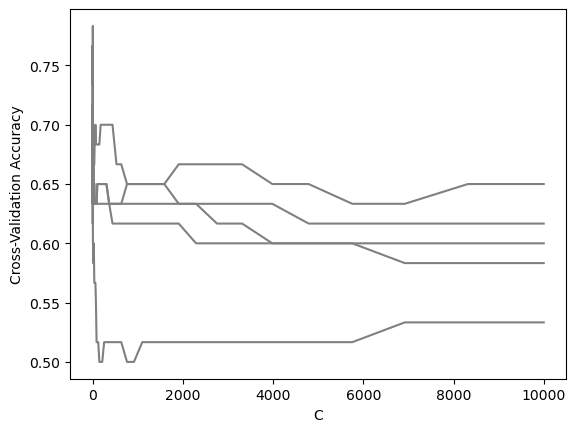

```python
fig, ax = plt.subplots()

ax.plot(ridge_tune.Cs_, ridge_tune.scores_[1.0].T, color="grey")
ax.set_xlabel("C")
ax.set_ylabel("Cross-Validation Accuracy")

plt.show()
```

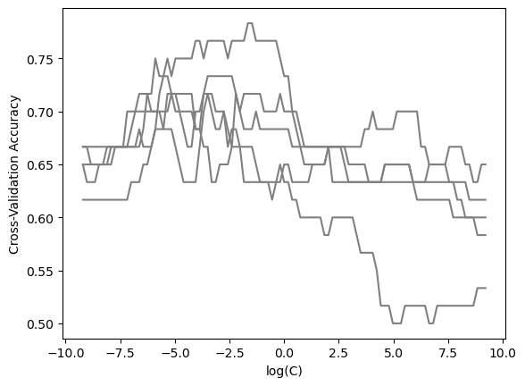

```python
fig, ax = plt.subplots()

ax.plot(np.log(ridge_tune.Cs_), ridge_tune.scores_[1.0].T, color="grey")
ax.set_xlabel("log(C)")
ax.set_ylabel("Cross-Validation Accuracy")

plt.show()
```

We are NOT interested in the behavior PER FOLD, we are interested in the behavior on AVERAGE across the FOLDS!

```python
ridge_tune.scores_[1.0].mean(axis=0).shape
```

```
(101,)
```

```python
ridge_tune.scores_[1.0].shape
```

```
(5, 101)
```

Include the AVERAGE performance as a BLUE LINE.

Lets include as a VERTICAL LINE the OPTIMAL or TUNED value for C.

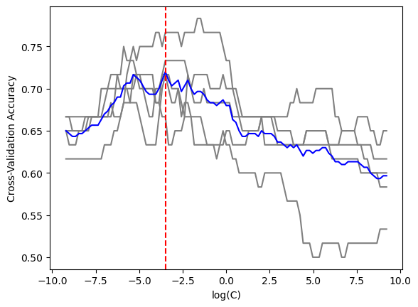

```python
fig, ax = plt.subplots()

ax.plot(np.log(ridge_tune.Cs_), ridge_tune.scores_[1.0].T, color="grey")
ax.plot(np.log(ridge_tune.Cs_), ridge_tune.scores_[1.0].mean(axis=0), color="blue")
ax.axvline(x=np.log(ridge_tune.C_), color="red", linestyle="dashed")
ax.set_xlabel("log(C)")
ax.set_ylabel("Cross-Validation Accuracy")

plt.show()
```

```python
ridge_tune.C_
```

```
array([0.03019952])
```

The TUNED ridge coefficients estimate are therefore in between the LARGE estimate that caused OVERFITTING and the SMALL estimates that produced NO TRENDS!!

```python
coef_compare["ridge_tuned_c"] = pd.Series(ridge_tune.coef_.ravel(), index=coef_compare.index)
```

```python
coef_compare
```

|  | statsmodels | sk_none | ridge_large_c | ridge_default_c | ridge_small_c | ridge_tuned_c |
| --- | --- | --- | --- | --- | --- | --- |
| Intercept | 1.320581 | 1.329038 | 1.321376 | 0.351903 | -0.003337 | -0.010144 |
| x5[T.b] | -1.552826 | -1.561391 | -1.554144 | -0.610448 | -0.002503 | -0.150766 |
| x5[T.c] | -0.022902 | -0.032790 | -0.026486 | 0.340784 | -0.000261 | 0.108363 |
| x1 | -0.998869 | -0.988951 | -0.996107 | 0.057703 | 0.001826 | 0.136925 |
| x5[T.b]:x1 | 1.210213 | 1.199890 | 1.207794 | 0.072722 | 0.000510 | -0.016060 |
| ... | ... | ... | ... | ... | ... | ... |
| x5[T.b]:np.power(x3, 4) | 0.416084 | 0.416293 | 0.415866 | 0.353882 | -0.003579 | 0.068877 |
| x5[T.c]:np.power(x3, 4) | 0.224892 | 0.224491 | 0.220873 | -0.003285 | -0.002141 | -0.002783 |
| np.power(x4, 4) | 0.284632 | 0.284389 | 0.284316 | -0.014937 | 0.000205 | 0.020031 |
| x5[T.b]:np.power(x4, 4) | -0.394857 | -0.394640 | -0.394545 | -0.056565 | -0.002540 | -0.019856 |
| x5[T.c]:np.power(x4, 4) | -1.348794 | -1.348266 | -1.338537 | -0.080741 | -0.002282 | -0.041725 |

81 rows × 6 columns

```python
coef_compare.sort_values(by=["sk_none"], ascending=False)
```

|  | statsmodels | sk_none | ridge_large_c | ridge_default_c | ridge_small_c | ridge_tuned_c |
| --- | --- | --- | --- | --- | --- | --- |
| x5[T.c]:np.power(x4, 2) | 7.767374 | 7.766503 | 7.709207 | 0.386651 | -0.000652 | 0.032908 |
| x5[T.c]:x1 | 4.669476 | 4.656514 | 4.640329 | 0.396514 | 0.000986 | 0.087384 |
| x5[T.b]:np.power(x2, 3) | 3.963076 | 3.976724 | 3.953294 | 0.046780 | -0.003096 | -0.067403 |
| x5[T.c]:x2:x3 | 3.796146 | 3.787374 | 3.771307 | -0.078134 | -0.000287 | -0.053645 |
| x5[T.b]:x1:x2 | 3.250150 | 3.249135 | 3.245968 | 1.177242 | 0.000239 | 0.156842 |
| ... | ... | ... | ... | ... | ... | ... |
| x5[T.c]:x3 | -3.703022 | -3.698450 | -3.696248 | -0.837395 | -0.000029 | -0.055554 |
| np.power(x2, 3) | -4.901121 | -4.914388 | -4.891419 | -0.930725 | -0.006798 | -0.284859 |
| x5[T.c]:x1:x2:x4 | -5.312586 | -5.316743 | -5.262944 | 0.291538 | 0.000263 | 0.037534 |
| x5[T.c]:x1:x2:x3 | -5.681986 | -5.679191 | -5.633929 | -0.578855 | -0.000779 | -0.072778 |
| x5[T.c]:np.power(x1, 2) | -6.117438 | -6.098547 | -6.074638 | -0.376093 | -0.001075 | 0.014036 |

81 rows × 6 columns

We have converted the COMPLEX model into a SIMPLER model!!!

Lets use PREDICTIONS to demonstrate this fact!!!

Use the same INPUT GRID as the grid used in Week 13.

```python
input_grid = pd.DataFrame([(x1, x2, x3, x4, x5) for x1 in np.linspace(df.x1.min(), df.x1.max(), num=101)
                                            for x2 in np.linspace(df.x2.min(), df.x2.max(), num=9)
                                            for x3 in [df.x3.mean()]
                                            for x4 in [df.x4.mean()]
                                            for x5 in df.x5.unique()],
                         columns=["x1", "x2", "x3", "x4", "x5"])
```

```python
input_grid.nunique()
```

```
x1    101
x2      9
x3      1
x4      1
x5      3
dtype: int64
```

Lets make the predictions from the COMPLEX MODEL that estimates the coefficients by ONLY minimizing the LOSS!!

```python
dfviz = input_grid.copy()
```

```python
dfviz["pred_prob_penalty_none"] = fit_stats.predict(input_grid)
```

```python
dfviz
```

|  | x1 | x2 | x3 | x4 | x5 | pred_prob_penalty_none |
| --- | --- | --- | --- | --- | --- | --- |
| 0 | -2.913116 | -3.008946 | 0.002302 | 0.001372 | c | 5.223184e-56 |
| 1 | -2.913116 | -3.008946 | 0.002302 | 0.001372 | b | 2.001029e-30 |
| 2 | -2.913116 | -3.008946 | 0.002302 | 0.001372 | a | 1.564839e-68 |
| 3 | -2.913116 | -2.242719 | 0.002302 | 0.001372 | c | 5.046389e-28 |
| 4 | -2.913116 | -2.242719 | 0.002302 | 0.001372 | b | 6.848157e-32 |
| ... | ... | ... | ... | ... | ... | ... |
| 2722 | 2.783826 | 2.354646 | 0.002302 | 0.001372 | b | 3.466483e-22 |
| 2723 | 2.783826 | 2.354646 | 0.002302 | 0.001372 | a | 1.004841e-71 |
| 2724 | 2.783826 | 3.120873 | 0.002302 | 0.001372 | c | 6.615981e-101 |
| 2725 | 2.783826 | 3.120873 | 0.002302 | 0.001372 | b | 1.566123e-35 |
| 2726 | 2.783826 | 3.120873 | 0.002302 | 0.001372 | a | 3.526699e-162 |

2727 rows × 6 columns

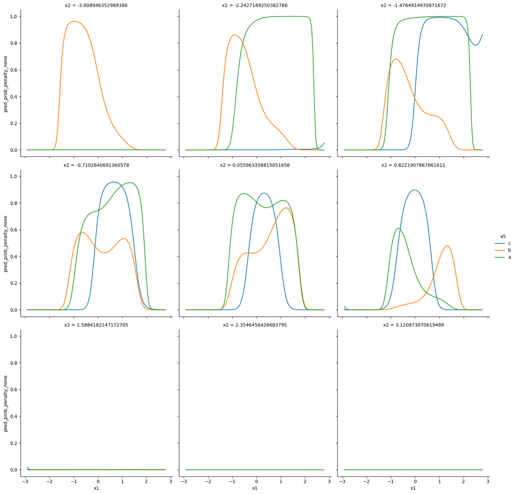

```python
sns.relplot(data=dfviz, x="x1", y="pred_prob_penalty_none", hue="x5",
            col="x2", kind="line",
            estimator=None,
            units="x5",
            col_wrap=3)

plt.show()
```

But now lets make predictions with the TUNED ridge penalized logistic regression model!

We need the FEATURE ARRAY for the new data.

```python
formula_list[-1][1:]
```

```
' ~ x5 * ( (x1 + x2 + x3 + x4) ** 3 + np.power(x1, 2) + np.power(x2 ,2) + np.power(x3 ,2) + np.power(x4 ,2) + np.power(x1, 3) + np.power(x2 ,3) + np.power(x3 ,3) + np.power(x4 ,3) + np.power(x1, 4) + np.power(x2 ,4) + np.power(x3 ,4) + np.power(x4 ,4))'
```

```python
Xgrid = dmatrix(formula_list[-1][1:], data=input_grid)
```

```python
Xgrid.shape
```

```
(2727, 81)
```

```python
x_sk.shape
```

```
(300, 81)
```

```python
pred_grid_ridge_tune = ridge_tune.predict_proba(Xgrid)
```

```python
pred_grid_ridge_tune[:5, :]
```

```
array([[1.00000000e+00, 5.34580079e-14],
       [1.00000000e+00, 3.89740817e-11],
       [1.00000000e+00, 3.69899542e-10],
       [1.00000000e+00, 7.13535532e-11],
       [1.00000000e+00, 4.71328021e-10]])
```

```python
ridge_tune.classes_
```

```
array([0., 1.])
```

```python
dfviz["pred_prob_ridge_tune"] = pd.Series(pred_grid_ridge_tune[:, ridge_tune.classes_==1].ravel(), index=dfviz.index)
```

```python
dfviz
```

|  | x1 | x2 | x3 | x4 | x5 | pred_prob_penalty_none | pred_prob_ridge_tune |
| --- | --- | --- | --- | --- | --- | --- | --- |
| 0 | -2.913116 | -3.008946 | 0.002302 | 0.001372 | c | 5.223184e-56 | 5.345801e-14 |
| 1 | -2.913116 | -3.008946 | 0.002302 | 0.001372 | b | 2.001029e-30 | 3.897408e-11 |
| 2 | -2.913116 | -3.008946 | 0.002302 | 0.001372 | a | 1.564839e-68 | 3.698995e-10 |
| 3 | -2.913116 | -2.242719 | 0.002302 | 0.001372 | c | 5.046389e-28 | 7.135355e-11 |
| 4 | -2.913116 | -2.242719 | 0.002302 | 0.001372 | b | 6.848157e-32 | 4.713280e-10 |
| ... | ... | ... | ... | ... | ... | ... | ... |
| 2722 | 2.783826 | 2.354646 | 0.002302 | 0.001372 | b | 3.466483e-22 | 1.311400e-09 |
| 2723 | 2.783826 | 2.354646 | 0.002302 | 0.001372 | a | 1.004841e-71 | 4.372802e-08 |
| 2724 | 2.783826 | 3.120873 | 0.002302 | 0.001372 | c | 6.615981e-101 | 7.306574e-18 |
| 2725 | 2.783826 | 3.120873 | 0.002302 | 0.001372 | b | 1.566123e-35 | 2.246960e-16 |
| 2726 | 2.783826 | 3.120873 | 0.002302 | 0.001372 | a | 3.526699e-162 | 6.543780e-14 |

2727 rows × 7 columns

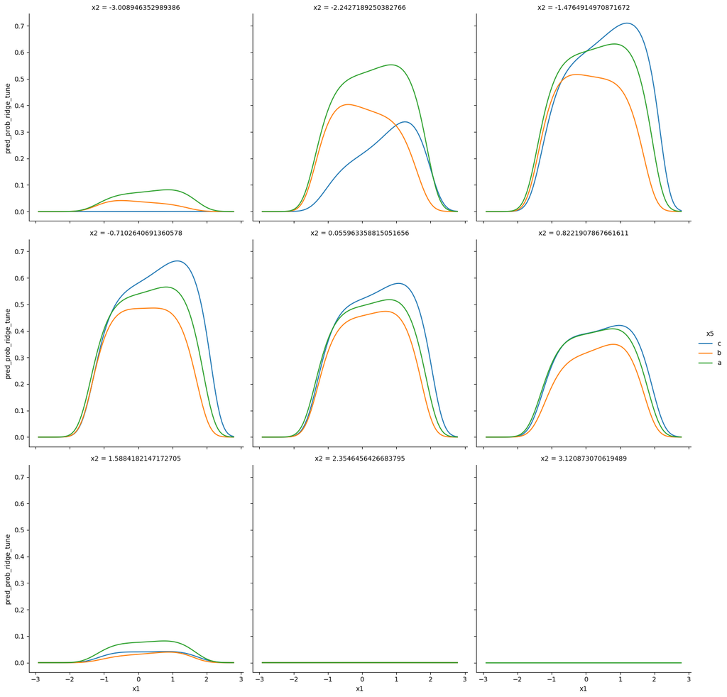

```python
sns.relplot(data=dfviz, x="x1", y="pred_prob_ridge_tune", hue="x5",
            col="x2", kind="line",
            estimator=None,
            units="x5",
            col_wrap=3)

plt.show()
```

## 2. LASSO Penalty

The RIDGE penalty pushes coefficients CLOSE TO but NEVER IDENTICALLY ZERO!!!

```python
coef_compare
```

|  | statsmodels | sk_none | ridge_large_c | ridge_default_c | ridge_small_c | ridge_tuned_c |
| --- | --- | --- | --- | --- | --- | --- |
| Intercept | 1.320581 | 1.329038 | 1.321376 | 0.351903 | -0.003337 | -0.010144 |
| x5[T.b] | -1.552826 | -1.561391 | -1.554144 | -0.610448 | -0.002503 | -0.150766 |
| x5[T.c] | -0.022902 | -0.032790 | -0.026486 | 0.340784 | -0.000261 | 0.108363 |
| x1 | -0.998869 | -0.988951 | -0.996107 | 0.057703 | 0.001826 | 0.136925 |
| x5[T.b]:x1 | 1.210213 | 1.199890 | 1.207794 | 0.072722 | 0.000510 | -0.016060 |
| ... | ... | ... | ... | ... | ... | ... |
| x5[T.b]:np.power(x3, 4) | 0.416084 | 0.416293 | 0.415866 | 0.353882 | -0.003579 | 0.068877 |
| x5[T.c]:np.power(x3, 4) | 0.224892 | 0.224491 | 0.220873 | -0.003285 | -0.002141 | -0.002783 |
| np.power(x4, 4) | 0.284632 | 0.284389 | 0.284316 | -0.014937 | 0.000205 | 0.020031 |
| x5[T.b]:np.power(x4, 4) | -0.394857 | -0.394640 | -0.394545 | -0.056565 | -0.002540 | -0.019856 |
| x5[T.c]:np.power(x4, 4) | -1.348794 | -1.348266 | -1.338537 | -0.080741 | -0.002282 | -0.041725 |

81 rows × 6 columns

The LASSO penalty FORCES the COEFFICIENTS associated with UNIMPORTANT FEATURES to be IDENTICALLY ZERO!!

The LASSO penalty therefore therefore **TURNS OFF** unimportant features!!

Just like the RIDGE penalty, the LASSO penalty ALSO has the C parameter. The C parameter dictates the COEFFICIENTS estimates. The IMAPCT of C is the same for LASSO and RIDGE but the LASSO penalty will literally cause unimportant features to have 0 for their coefficient.

The LASSO penalty is also known as the L1-norm so the penalty-l1 and you must change the solver="saga".

Lets try out 3 values for C to confirm the IMPACT of C on the coefficient estimates for LASSO.

Start with the DEFAULT value C=1.

```python
lasso_default_C = LogisticRegression(penalty="l1", solver="saga", C=1.0, max_iter=25001, fit_intercept=False).\
fit(x_sk, y_sk.ravel())
```

```python
lasso_default_C.score(x_sk, y_sk.ravel())
```

```
0.7866666666666666
```

```python
ridge_default_C.score(x_sk, y_sk.ravel())
```

```
0.8033333333333333
```

```python
fit_sk_none.score(x_sk, y_sk.ravel())
```

```
0.8133333333333334
```

```python
lasso_default_C.coef_
```

```
array([[ 0.1234477 , -0.37239416,  0.402141  ,  0.18867727,  0.        ,
         0.18932636, -0.35796716,  0.        ,  0.        ,  0.30555543,
         0.52278008, -0.2556662 , -0.22832068,  0.06951078, -0.1770049 ,
        -0.07315379,  0.74339327, -0.58743917, -0.11818272, -0.05914976,
         0.1073288 ,  0.09666917, -0.47710427,  0.07227065,  0.0559351 ,
         0.40131228, -0.04230038, -0.12021808,  0.        ,  0.        ,
         0.21630446, -0.02770289,  0.15665646, -0.10459712,  0.        ,
        -0.23704244,  0.02746247,  0.        ,  0.02710035, -0.02307715,
         0.07789351, -0.0090719 , -0.05167073,  0.02821527, -0.15843491,
         0.1037661 ,  0.02305578,  0.        , -0.03979769, -0.74354689,
         0.        , -0.57969864, -0.22775993,  0.04634329,  0.32365195,
         0.0104259 ,  0.        ,  0.3681189 ,  0.00570457,  0.        ,
        -0.67356513,  0.        ,  0.        , -0.10957813,  0.09445669,
         0.00376529,  0.03375161,  0.        ,  0.22120629, -0.38453867,
         0.01626706,  0.        , -0.27522331,  0.08976758, -0.15169049,
         0.05871285,  0.21250557,  0.01334177, -0.01929415, -0.01641985,
        -0.04526545]])
```

```python
ridge_default_C.coef_ == 0
```

```
array([[False, False, False, False, False, False, False, False, False,
        False, False, False, False, False, False, False, False, False,
        False, False, False, False, False, False, False, False, False,
        False, False, False, False, False, False, False, False, False,
        False, False, False, False, False, False, False, False, False,
        False, False, False, False, False, False, False, False, False,
        False, False, False, False, False, False, False, False, False,
        False, False, False, False, False, False, False, False, False,
        False, False, False, False, False, False, False, False, False]])
```

```python
lasso_default_C.coef_ == 0
```

```
array([[False, False, False, False,  True, False, False,  True,  True,
        False, False, False, False, False, False, False, False, False,
        False, False, False, False, False, False, False, False, False,
        False,  True,  True, False, False, False, False,  True, False,
        False,  True, False, False, False, False, False, False, False,
        False, False,  True, False, False,  True, False, False, False,
        False, False,  True, False, False,  True, False,  True,  True,
        False, False, False, False,  True, False, False, False,  True,
        False, False, False, False, False, False, False, False, False]])
```

Try VERY LARGE values for C with LASSO.

```python
lasso_large_C = LogisticRegression(penalty="l1", solver="saga", C=10000, max_iter=25001, fit_intercept=False).\
fit(x_sk, y_sk.ravel())
```

```python
lasso_large_C.score(x_sk, y_sk.ravel())
```

```
0.8
```

```python
ridge_large_C.score(x_sk, y_sk.ravel())
```

```
0.8133333333333334
```

```python
fit_sk_none.score(x_sk, y_sk.ravel())
```

```
0.8133333333333334
```

```python
lasso_large_C.coef_
```

```
array([[ 2.82692409e-01, -5.69450259e-01,  4.06912904e-01,
         1.96533859e-01, -5.57803286e-02,  3.17819939e-01,
        -4.70584283e-01,  9.13133671e-02,  7.93307470e-02,
         5.44262381e-01,  6.22464441e-01, -6.05665275e-01,
        -4.73961302e-01,  3.08841798e-01, -4.21149790e-01,
        -1.97443445e-01,  1.03379750e+00, -7.50712988e-01,
        -2.77250366e-01, -1.23773807e-01,  2.72275203e-01,
         2.31222689e-01, -6.95228797e-01,  2.44023480e-01,
         2.13288988e-01,  5.24836193e-01, -2.03115915e-01,
        -2.77096834e-01,  1.38933830e-01,  5.82389900e-02,
         3.22866939e-01, -1.72166971e-01,  1.72309480e-01,
        -2.76341024e-01,  1.49812561e-01, -4.07494918e-01,
         2.52292612e-01, -2.55158578e-01,  2.80840820e-01,
        -1.72425301e-01,  3.30959598e-01, -1.75375474e-01,
        -2.98863693e-01,  3.11693557e-01, -4.14348796e-01,
         2.97444993e-01,  1.79537569e-01, -9.60629361e-02,
        -1.86663082e-01, -9.36677314e-01,  2.51936446e-01,
        -8.49225886e-01, -4.95067858e-01,  9.25065422e-02,
         3.26056682e-01,  2.19379030e-01,  2.13469969e-01,
         4.20141857e-01,  1.43367916e-01,  5.91629361e-02,
        -8.31864562e-01, -8.21647077e-02,  1.27197653e-01,
        -1.67933480e-01,  1.43826957e-01,  4.62952219e-02,
         7.84600270e-02, -4.67055790e-02,  3.59232725e-01,
        -5.17280103e-01, -1.23203207e-02,  6.56047894e-04,
        -3.20890444e-01,  9.95179880e-02, -1.97783632e-01,
         1.00044087e-01,  3.35297834e-01,  4.56734762e-03,
        -2.86179193e-02, -4.15129497e-02, -6.66267809e-02]])
```

Push C to the other extreme where C is VERY SMALL.

```python
lasso_small_C = LogisticRegression(penalty="l1", solver="saga", C=.0001, max_iter=25001, fit_intercept=False).\
fit(x_sk, y_sk.ravel())
```

```python
lasso_small_C.score(x_sk, y_sk.ravel())
```

```
0.66
```

```python
ridge_small_C.score(x_sk, y_sk.ravel())
```

```
0.6633333333333333
```

```python
fit_sk_0.score(x_0, y_0.ravel())
```

```
0.66
```

VERY SMALL values of C force the COMPLEX MODEL to behave like the INTERCEPT-ONLY model which has no TRENDS!!!

```python
lasso_small_C.coef_
```

```
array([[0., 0., 0., 0., 0., 0., 0., 0., 0., 0., 0., 0., 0., 0., 0., 0.,
        0., 0., 0., 0., 0., 0., 0., 0., 0., 0., 0., 0., 0., 0., 0., 0.,
        0., 0., 0., 0., 0., 0., 0., 0., 0., 0., 0., 0., 0., 0., 0., 0.,
        0., 0., 0., 0., 0., 0., 0., 0., 0., 0., 0., 0., 0., 0., 0., 0.,
        0., 0., 0., 0., 0., 0., 0., 0., 0., 0., 0., 0., 0., 0., 0., 0.,
        0.]])
```

ALL FEATURES HAVE BEEN TURNED OFFF!! The LASSO Penalty has literally converted the VERY COMPLEX MODEL iwht 81 features into a model with NO TRENDS!!!

Just as with RIDGE, we need to use CV to identify the BEST value of C!!!!

Tuning C for LASSO identifies the MOST IMPORTANT features needed!!!!!!

```python
lasso_tune = LogisticRegressionCV(penalty="l1", solver="saga", Cs=101, cv=kf, max_iter=25001, fit_intercept=False).\
fit(x_sk, y_sk.ravel())
```

The optimal value for C is:

```python
lasso_tune.C_
```

```
array([0.05248075])
```

The CV performance can be visualized just like the RIDGE CV performance!

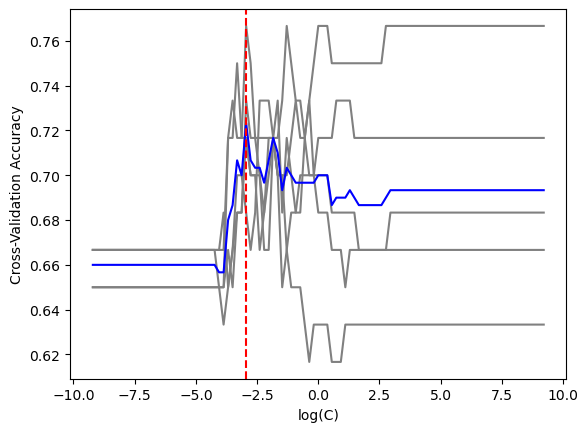

```python
fig, ax = plt.subplots()

ax.plot(np.log(lasso_tune.Cs_), lasso_tune.scores_[1.0].T, color="grey")
ax.plot(np.log(lasso_tune.Cs_), lasso_tune.scores_[1.0].mean(axis=0), color="blue")
ax.axvline(x=np.log(lasso_tune.C_), color="red", linestyle="dashed")
ax.set_xlabel("log(C)")
ax.set_ylabel("Cross-Validation Accuracy")

plt.show()
```

Which coefficients are zero??

```python
lasso_tune.coef_
```

```
array([[ 0.        ,  0.        ,  0.        ,  0.        ,  0.        ,
         0.        ,  0.        ,  0.        ,  0.        ,  0.        ,
         0.        ,  0.        ,  0.        ,  0.        ,  0.        ,
         0.        ,  0.        ,  0.        ,  0.        ,  0.        ,
         0.        ,  0.        ,  0.        ,  0.        ,  0.        ,
         0.        ,  0.        ,  0.        ,  0.        ,  0.        ,
         0.        ,  0.        ,  0.        ,  0.        ,  0.        ,
         0.        ,  0.        ,  0.        ,  0.        ,  0.        ,
         0.        ,  0.        ,  0.        ,  0.        ,  0.        ,
         0.        ,  0.        ,  0.        ,  0.        ,  0.        ,
         0.        ,  0.        ,  0.        ,  0.        ,  0.        ,
         0.        ,  0.        ,  0.09806621,  0.        ,  0.        ,
        -0.27388049,  0.        ,  0.        ,  0.        ,  0.01085482,
         0.        ,  0.        ,  0.        ,  0.        , -0.16184923,
         0.        ,  0.        , -0.14373746,  0.        ,  0.        ,
        -0.02185294,  0.        ,  0.        ,  0.00613386,  0.        ,
         0.        ]])
```

Which specific features are **NOT** turned off?

```python
coef_compare
```

|  | statsmodels | sk_none | ridge_large_c | ridge_default_c | ridge_small_c | ridge_tuned_c |
| --- | --- | --- | --- | --- | --- | --- |
| Intercept | 1.320581 | 1.329038 | 1.321376 | 0.351903 | -0.003337 | -0.010144 |
| x5[T.b] | -1.552826 | -1.561391 | -1.554144 | -0.610448 | -0.002503 | -0.150766 |
| x5[T.c] | -0.022902 | -0.032790 | -0.026486 | 0.340784 | -0.000261 | 0.108363 |
| x1 | -0.998869 | -0.988951 | -0.996107 | 0.057703 | 0.001826 | 0.136925 |
| x5[T.b]:x1 | 1.210213 | 1.199890 | 1.207794 | 0.072722 | 0.000510 | -0.016060 |
| ... | ... | ... | ... | ... | ... | ... |
| x5[T.b]:np.power(x3, 4) | 0.416084 | 0.416293 | 0.415866 | 0.353882 | -0.003579 | 0.068877 |
| x5[T.c]:np.power(x3, 4) | 0.224892 | 0.224491 | 0.220873 | -0.003285 | -0.002141 | -0.002783 |
| np.power(x4, 4) | 0.284632 | 0.284389 | 0.284316 | -0.014937 | 0.000205 | 0.020031 |
| x5[T.b]:np.power(x4, 4) | -0.394857 | -0.394640 | -0.394545 | -0.056565 | -0.002540 | -0.019856 |
| x5[T.c]:np.power(x4, 4) | -1.348794 | -1.348266 | -1.338537 | -0.080741 | -0.002282 | -0.041725 |

81 rows × 6 columns

```python
coef_compare["lasso_tuned_c"] = pd.Series(lasso_tune.coef_.ravel(), index=coef_compare.index)
```

```python
coef_compare.loc[coef_compare.lasso_tuned_c != 0]
```

|  | statsmodels | sk_none | ridge_large_c | ridge_default_c | ridge_small_c | ridge_tuned_c | lasso_tuned_c |
| --- | --- | --- | --- | --- | --- | --- | --- |
| np.power(x1, 3) | 1.546910 | 1.539273 | 1.543822 | 0.481817 | 0.003075 | 0.161669 | 0.098066 |
| np.power(x2, 3) | -4.901121 | -4.914388 | -4.891419 | -0.930725 | -0.006798 | -0.284859 | -0.273880 |
| x5[T.b]:np.power(x3, 3) | 0.631191 | 0.630231 | 0.630890 | 0.179202 | 0.002604 | 0.108703 | 0.010855 |
| np.power(x1, 4) | -1.163830 | -1.157763 | -1.161115 | -0.532805 | -0.020233 | -0.199678 | -0.161849 |
| np.power(x2, 4) | -1.854168 | -1.859893 | -1.849206 | -0.358927 | -0.015878 | -0.123011 | -0.143737 |
| np.power(x3, 4) | 0.263377 | 0.263345 | 0.263379 | 0.104120 | -0.011490 | 0.008523 | -0.021853 |
| np.power(x4, 4) | 0.284632 | 0.284389 | 0.284316 | -0.014937 | 0.000205 | 0.020031 | 0.006134 |

The TUNED LASSO model is MUCH SIMPLER with just 7 effective FEATURES instead of 81!!!!

Lets visualize the simplified model by making predictions with the TUNED LASSO model!!!

```python
pred_grid_lasso_tune = lasso_tune.predict_proba(Xgrid)
```

```python
pred_grid_lasso_tune
```

```
array([[9.99999990e-01, 1.01964467e-08],
       [9.99999990e-01, 1.01964467e-08],
       [9.99999990e-01, 1.01964467e-08],
       ...,
       [1.00000000e+00, 1.44524095e-13],
       [1.00000000e+00, 1.44524095e-13],
       [1.00000000e+00, 1.44524095e-13]])
```

```python
lasso_tune.classes_
```

```
array([0., 1.])
```

```python
dfviz
```

|  | x1 | x2 | x3 | x4 | x5 | pred_prob_penalty_none | pred_prob_ridge_tune |
| --- | --- | --- | --- | --- | --- | --- | --- |
| 0 | -2.913116 | -3.008946 | 0.002302 | 0.001372 | c | 5.223184e-56 | 5.345801e-14 |
| 1 | -2.913116 | -3.008946 | 0.002302 | 0.001372 | b | 2.001029e-30 | 3.897408e-11 |
| 2 | -2.913116 | -3.008946 | 0.002302 | 0.001372 | a | 1.564839e-68 | 3.698995e-10 |
| 3 | -2.913116 | -2.242719 | 0.002302 | 0.001372 | c | 5.046389e-28 | 7.135355e-11 |
| 4 | -2.913116 | -2.242719 | 0.002302 | 0.001372 | b | 6.848157e-32 | 4.713280e-10 |
| ... | ... | ... | ... | ... | ... | ... | ... |
| 2722 | 2.783826 | 2.354646 | 0.002302 | 0.001372 | b | 3.466483e-22 | 1.311400e-09 |
| 2723 | 2.783826 | 2.354646 | 0.002302 | 0.001372 | a | 1.004841e-71 | 4.372802e-08 |
| 2724 | 2.783826 | 3.120873 | 0.002302 | 0.001372 | c | 6.615981e-101 | 7.306574e-18 |
| 2725 | 2.783826 | 3.120873 | 0.002302 | 0.001372 | b | 1.566123e-35 | 2.246960e-16 |
| 2726 | 2.783826 | 3.120873 | 0.002302 | 0.001372 | a | 3.526699e-162 | 6.543780e-14 |

2727 rows × 7 columns

```python
dfviz["pred_prob_lasso_tune"] = pd.Series(pred_grid_lasso_tune[:, lasso_tune.classes_==1].ravel(), index=dfviz.index)
```

```python
dfviz
```

|  | x1 | x2 | x3 | x4 | x5 | pred_prob_penalty_none | pred_prob_ridge_tune | pred_prob_lasso_tune |
| --- | --- | --- | --- | --- | --- | --- | --- | --- |
| 0 | -2.913116 | -3.008946 | 0.002302 | 0.001372 | c | 5.223184e-56 | 5.345801e-14 | 1.019645e-08 |
| 1 | -2.913116 | -3.008946 | 0.002302 | 0.001372 | b | 2.001029e-30 | 3.897408e-11 | 1.019645e-08 |
| 2 | -2.913116 | -3.008946 | 0.002302 | 0.001372 | a | 1.564839e-68 | 3.698995e-10 | 1.019645e-08 |
| 3 | -2.913116 | -2.242719 | 0.002302 | 0.001372 | c | 5.046389e-28 | 7.135355e-11 | 4.441887e-07 |
| 4 | -2.913116 | -2.242719 | 0.002302 | 0.001372 | b | 6.848157e-32 | 4.713280e-10 | 4.441887e-07 |
| ... | ... | ... | ... | ... | ... | ... | ... | ... |
| 2722 | 2.783826 | 2.354646 | 0.002302 | 0.001372 | b | 3.466483e-22 | 1.311400e-09 | 1.681166e-07 |
| 2723 | 2.783826 | 2.354646 | 0.002302 | 0.001372 | a | 1.004841e-71 | 4.372802e-08 | 1.681166e-07 |
| 2724 | 2.783826 | 3.120873 | 0.002302 | 0.001372 | c | 6.615981e-101 | 7.306574e-18 | 1.445241e-13 |
| 2725 | 2.783826 | 3.120873 | 0.002302 | 0.001372 | b | 1.566123e-35 | 2.246960e-16 | 1.445241e-13 |
| 2726 | 2.783826 | 3.120873 | 0.002302 | 0.001372 | a | 3.526699e-162 | 6.543780e-14 | 1.445241e-13 |

2727 rows × 8 columns

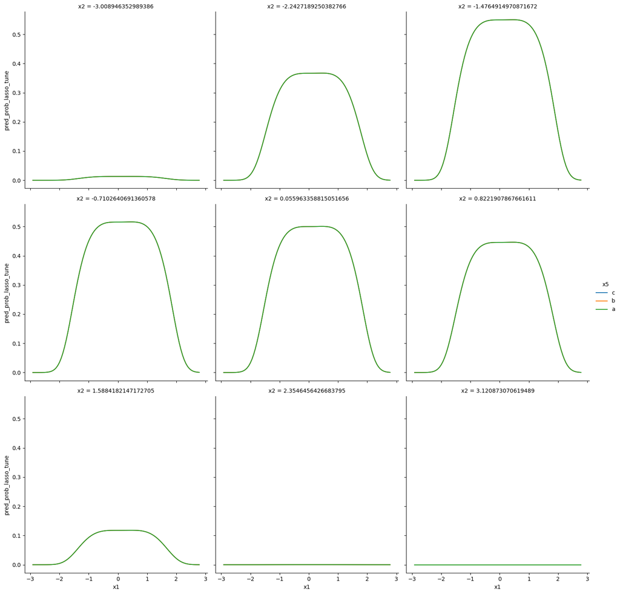

```python
sns.relplot(data=dfviz, x="x1", y="pred_prob_lasso_tune", col="x2", hue="x5",
            estimator=None,
            units="x2", kind="line",
           col_wrap=3)

plt.show()
```

## 3. ELASTIC NET Penalty

We have seen how RIDGE pushes coefficients NEAR ZERo but NEVER identically zero.

We have seen LASSO literally turn off unimportant features!!!

But which of the two methods should you use??

One approach is to TRY BOTH and use CV to identify the BETTER of the TWO!!!

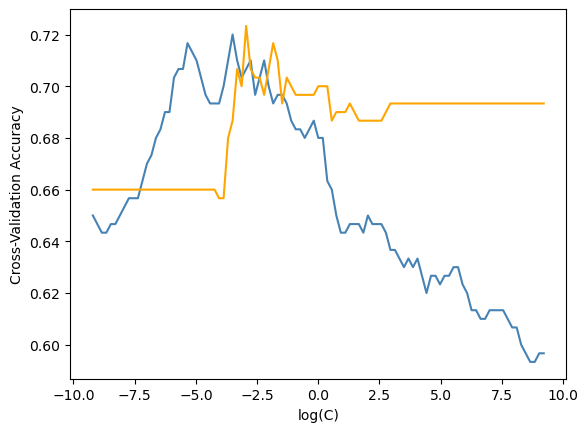

```python
fig, ax = plt.subplots()
ax.plot(np.log(ridge_tune.Cs_), ridge_tune.scores_[1.0].mean(axis=0), color="steelblue", label="Ridge")
ax.plot(np.log(lasso_tune.Cs_), lasso_tune.scores_[1.0].mean(axis=0), color="orange", label="Lasso")

ax.set_xlabel("log(C)")
ax.set_ylabel("Cross-Validation Accuracy")

plt.show()
```

HOWEVER...rather than just trying out the TWO..WHAT IF we could **BLEND** or **MIX** Lasso and Ridge together??

This is the mindset of the ELASTIC NET penalty!!! It MIXES LASSO and RIDGE to try and get the BENEFITS of BOTH!!!!

The ENET penalty ALSO has the C parameter to CONTROL how the coefficients are estimates. The C parameter IMPACT is IDENTICAL to the LASSO and RIDGE C paramter impact!!!

BUT...ENET has a **SECOND** TUNING parameter that must be defined!! The second tuning paramter is MIXING FRACTION between LASSO and RIDGE!!! This MIXING FRACTION is known as the l1-ratio.

Lets fit an ENET penalized model with a MIXING FRACTION of 0.5 and the DEFAULT C value.

```python
enet_even_mix = LogisticRegression(penalty="elasticnet",
                                     solver="saga",
                                     C=1.0,
                                     l1_ratio=0.5,
                                      max_iter=25001,
                                     fit_intercept=False).fit(x_sk, y_sk.ravel())
```

```python
enet_even_mix.score(x_sk, y_sk.ravel())
```

```
0.7966666666666666
```

```python
lasso_default_C.score(x_sk, y_sk.ravel())
```

```
0.7866666666666666
```

```python
ridge_default_C.score(x_sk, y_sk.ravel())
```

```
0.8033333333333333
```

```python
enet_even_mix.coef_ == 0
```

```
array([[False, False, False, False,  True, False, False, False,  True,
        False, False, False, False, False, False, False, False, False,
        False, False, False, False, False, False, False, False, False,
        False, False,  True, False, False, False, False, False, False,
        False, False, False, False, False, False, False, False, False,
        False, False,  True, False, False, False, False, False, False,
        False, False, False, False, False,  True, False, False, False,
        False, False, False, False, False, False, False, False,  True,
        False, False, False, False, False, False, False, False, False]])
```

TUNING Elastic Net requires TUNING **BOTH** the C paramter **AND** the l1-ratio.

Lets use the same stratified 5-fold CV approach that we used previously.

```python
enet_tune = LogisticRegressionCV(penalty="elasticnet",
                                 solver="saga",
                                 Cs=25,
                                 l1_ratios=np.linspace(0,1, num=7),
                                 max_iter=25001,
                                 cv=kf,
                                 fit_intercept=False).fit(x_sk, y_sk.ravel())
```

If the l1-ratio = 0, Elastic Net has turned to RIDGE.  
If the l1-ratio = 1, Elastic Net has turned to LASSO.

```python
enet_tune.C_
```

```
array([0.04641589])
```

```python
enet_tune.l1_ratio_
```

```
array([0.83333333])
```

The TUNED elastic net model is CLOSER TO LASSO THAN RIDGE!!!

We will NOT visualize the ELASTIC NET cross-validation results because it takes more data manipulationg to create the figure.

```python
enet_tune.scores_[1.0].shape
```

```
(5, 25, 7)
```